# Risk Factor Analysis

## Outcome Variable

**Outcome Variable:** ever_wasted

## Predictor Variables

**Intervention Variable:** meducyrs

**Adjustment Set:**

- arm
- W_mage
- feducyrs
- hhwealth_quart
- W_mhtcm
- W_mwtkg
- W_mbmi
- W_gagebrth
- W_birthwt
- W_birthlen
- single
- impsan
- delta_W_mage
- delta_feducyrs
- delta_hhwealth_quart
- delta_W_mhtcm
- delta_W_mwtkg
- delta_W_mbmi
- delta_W_gagebrth
- delta_W_birthwt
- delta_W_birthlen
- delta_single
- delta_impsan

## Stratifying Variables

The analysis was stratified on these variable(s):

- agecat
- studyid
- country

## Data Summary

| agecat | studyid | country | meducyrs | ever_wasted | n_cell | n |
| --- | --- | --- | --- | --- | --- | --- |
| 0-24 months | ki0047075b-MAL-ED | BANGLADESH | High | 0 | 59 | 213 |
| 0-24 months | ki0047075b-MAL-ED | BANGLADESH | High | 1 | 19 | 213 |
| 0-24 months | ki0047075b-MAL-ED | BANGLADESH | Low | 0 | 46 | 213 |
| 0-24 months | ki0047075b-MAL-ED | BANGLADESH | Low | 1 | 24 | 213 |
| 0-24 months | ki0047075b-MAL-ED | BANGLADESH | Medium | 0 | 44 | 213 |
| 0-24 months | ki0047075b-MAL-ED | BANGLADESH | Medium | 1 | 21 | 213 |
| 0-24 months | ki0047075b-MAL-ED | BRAZIL | High | 0 | 76 | 232 |
| 0-24 months | ki0047075b-MAL-ED | BRAZIL | High | 1 | 3 | 232 |
| 0-24 months | ki0047075b-MAL-ED | BRAZIL | Low | 0 | 55 | 232 |
| 0-24 months | ki0047075b-MAL-ED | BRAZIL | Low | 1 | 8 | 232 |
| 0-24 months | ki0047075b-MAL-ED | BRAZIL | Medium | 0 | 81 | 232 |
| 0-24 months | ki0047075b-MAL-ED | BRAZIL | Medium | 1 | 9 | 232 |
| 0-24 months | ki0047075b-MAL-ED | INDIA | High | 0 | 38 | 220 |
| 0-24 months | ki0047075b-MAL-ED | INDIA | High | 1 | 25 | 220 |
| 0-24 months | ki0047075b-MAL-ED | INDIA | Low | 0 | 34 | 220 |
| 0-24 months | ki0047075b-MAL-ED | INDIA | Low | 1 | 42 | 220 |
| 0-24 months | ki0047075b-MAL-ED | INDIA | Medium | 0 | 44 | 220 |
| 0-24 months | ki0047075b-MAL-ED | INDIA | Medium | 1 | 37 | 220 |
| 0-24 months | ki0047075b-MAL-ED | NEPAL | High | 0 | 39 | 225 |
| 0-24 months | ki0047075b-MAL-ED | NEPAL | High | 1 | 14 | 225 |
| 0-24 months | ki0047075b-MAL-ED | NEPAL | Low | 0 | 66 | 225 |
| 0-24 months | ki0047075b-MAL-ED | NEPAL | Low | 1 | 30 | 225 |
| 0-24 months | ki0047075b-MAL-ED | NEPAL | Medium | 0 | 50 | 225 |
| 0-24 months | ki0047075b-MAL-ED | NEPAL | Medium | 1 | 26 | 225 |
| 0-24 months | ki0047075b-MAL-ED | PERU | High | 0 | 87 | 301 |
| 0-24 months | ki0047075b-MAL-ED | PERU | High | 1 | 3 | 301 |
| 0-24 months | ki0047075b-MAL-ED | PERU | Low | 0 | 92 | 301 |
| 0-24 months | ki0047075b-MAL-ED | PERU | Low | 1 | 12 | 301 |
| 0-24 months | ki0047075b-MAL-ED | PERU | Medium | 0 | 95 | 301 |
| 0-24 months | ki0047075b-MAL-ED | PERU | Medium | 1 | 12 | 301 |

[output cut: 438 more lines]

The following strata were considered:

- agecat: 0-24 months, studyid: ki0047075b-MAL-ED, country: BANGLADESH
- agecat: 0-24 months, studyid: ki0047075b-MAL-ED, country: BRAZIL
- agecat: 0-24 months, studyid: ki0047075b-MAL-ED, country: INDIA
- agecat: 0-24 months, studyid: ki0047075b-MAL-ED, country: NEPAL
- agecat: 0-24 months, studyid: ki0047075b-MAL-ED, country: PERU
- agecat: 0-24 months, studyid: ki0047075b-MAL-ED, country: SOUTH AFRICA
- agecat: 0-24 months, studyid: ki0047075b-MAL-ED, country: TANZANIA, UNITED REPUBLIC OF
- agecat: 0-24 months, studyid: ki1000108-CMC-V-BCS-2002, country: INDIA
- agecat: 0-24 months, studyid: ki1000108-IRC, country: INDIA
- agecat: 0-24 months, studyid: ki1000109-EE, country: PAKISTAN
- agecat: 0-24 months, studyid: ki1000304b-SAS-CompFeed, country: INDIA
- agecat: 0-24 months, studyid: ki1000304b-SAS-FoodSuppl, country: INDIA
- agecat: 0-24 months, studyid: ki1017093-NIH-Birth, country: BANGLADESH
- agecat: 0-24 months, studyid: ki1017093b-PROVIDE, country: BANGLADESH
- agecat: 0-24 months, studyid: ki1017093c-NIH-Crypto, country: BANGLADESH
- agecat: 0-24 months, studyid: ki1066203-TanzaniaChild2, country: TANZANIA, UNITED REPUBLIC OF
- agecat: 0-24 months, studyid: ki1112895-Guatemala BSC, country: GUATEMALA
- agecat: 0-24 months, studyid: ki1113344-GMS-Nepal, country: NEPAL
- agecat: 0-24 months, studyid: ki1119695-PROBIT, country: BELARUS
- agecat: 0-24 months, studyid: ki1126311-ZVITAMBO, country: ZIMBABWE
- agecat: 0-24 months, studyid: ki1135781-COHORTS, country: GUATEMALA
- agecat: 0-24 months, studyid: ki1135781-COHORTS, country: INDIA
- agecat: 0-24 months, studyid: ki1135781-COHORTS, country: PHILIPPINES
- agecat: 0-24 months, studyid: ki1148112-LCNI-5, country: MALAWI
- agecat: 0-24 months, studyid: kiGH5241-JiVitA-3, country: BANGLADESH
- agecat: 0-24 months, studyid: kiGH5241-JiVitA-4, country: BANGLADESH
- agecat: 0-6 months, studyid: ki0047075b-MAL-ED, country: BANGLADESH
- agecat: 0-6 months, studyid: ki0047075b-MAL-ED, country: BRAZIL
- agecat: 0-6 months, studyid: ki0047075b-MAL-ED, country: INDIA
- agecat: 0-6 months, studyid: ki0047075b-MAL-ED, country: NEPAL
- agecat: 0-6 months, studyid: ki0047075b-MAL-ED, country: PERU
- agecat: 0-6 months, studyid: ki0047075b-MAL-ED, country: SOUTH AFRICA
- agecat: 0-6 months, studyid: ki0047075b-MAL-ED, country: TANZANIA, UNITED REPUBLIC OF
- agecat: 0-6 months, studyid: ki1000108-CMC-V-BCS-2002, country: INDIA
- agecat: 0-6 months, studyid: ki1000108-IRC, country: INDIA
- agecat: 0-6 months, studyid: ki1000109-EE, country: PAKISTAN
- agecat: 0-6 months, studyid: ki1000304b-SAS-CompFeed, country: INDIA
- agecat: 0-6 months, studyid: ki1000304b-SAS-FoodSuppl, country: INDIA
- agecat: 0-6 months, studyid: ki1017093-NIH-Birth, country: BANGLADESH
- agecat: 0-6 months, studyid: ki1017093b-PROVIDE, country: BANGLADESH
- agecat: 0-6 months, studyid: ki1017093c-NIH-Crypto, country: BANGLADESH
- agecat: 0-6 months, studyid: ki1066203-TanzaniaChild2, country: TANZANIA, UNITED REPUBLIC OF
- agecat: 0-6 months, studyid: ki1112895-Guatemala BSC, country: GUATEMALA
- agecat: 0-6 months, studyid: ki1113344-GMS-Nepal, country: NEPAL
- agecat: 0-6 months, studyid: ki1119695-PROBIT, country: BELARUS
- agecat: 0-6 months, studyid: ki1126311-ZVITAMBO, country: ZIMBABWE
- agecat: 0-6 months, studyid: ki1135781-COHORTS, country: GUATEMALA
- agecat: 0-6 months, studyid: ki1135781-COHORTS, country: INDIA
- agecat: 0-6 months, studyid: ki1135781-COHORTS, country: PHILIPPINES
- agecat: 0-6 months, studyid: ki1148112-LCNI-5, country: MALAWI
- agecat: 0-6 months, studyid: kiGH5241-JiVitA-3, country: BANGLADESH
- agecat: 0-6 months, studyid: kiGH5241-JiVitA-4, country: BANGLADESH
- agecat: 6-24 months, studyid: ki0047075b-MAL-ED, country: BANGLADESH
- agecat: 6-24 months, studyid: ki0047075b-MAL-ED, country: BRAZIL
- agecat: 6-24 months, studyid: ki0047075b-MAL-ED, country: INDIA
- agecat: 6-24 months, studyid: ki0047075b-MAL-ED, country: NEPAL
- agecat: 6-24 months, studyid: ki0047075b-MAL-ED, country: PERU
- agecat: 6-24 months, studyid: ki0047075b-MAL-ED, country: SOUTH AFRICA
- agecat: 6-24 months, studyid: ki0047075b-MAL-ED, country: TANZANIA, UNITED REPUBLIC OF
- agecat: 6-24 months, studyid: ki1000108-CMC-V-BCS-2002, country: INDIA
- agecat: 6-24 months, studyid: ki1000108-IRC, country: INDIA
- agecat: 6-24 months, studyid: ki1000109-EE, country: PAKISTAN
- agecat: 6-24 months, studyid: ki1000304b-SAS-CompFeed, country: INDIA
- agecat: 6-24 months, studyid: ki1000304b-SAS-FoodSuppl, country: INDIA
- agecat: 6-24 months, studyid: ki1017093-NIH-Birth, country: BANGLADESH
- agecat: 6-24 months, studyid: ki1017093b-PROVIDE, country: BANGLADESH
- agecat: 6-24 months, studyid: ki1017093c-NIH-Crypto, country: BANGLADESH
- agecat: 6-24 months, studyid: ki1066203-TanzaniaChild2, country: TANZANIA, UNITED REPUBLIC OF
- agecat: 6-24 months, studyid: ki1112895-Guatemala BSC, country: GUATEMALA
- agecat: 6-24 months, studyid: ki1113344-GMS-Nepal, country: NEPAL
- agecat: 6-24 months, studyid: ki1119695-PROBIT, country: BELARUS
- agecat: 6-24 months, studyid: ki1126311-ZVITAMBO, country: ZIMBABWE
- agecat: 6-24 months, studyid: ki1135781-COHORTS, country: GUATEMALA
- agecat: 6-24 months, studyid: ki1135781-COHORTS, country: INDIA
- agecat: 6-24 months, studyid: ki1135781-COHORTS, country: PHILIPPINES
- agecat: 6-24 months, studyid: ki1148112-LCNI-5, country: MALAWI
- agecat: 6-24 months, studyid: kiGH5241-JiVitA-3, country: BANGLADESH
- agecat: 6-24 months, studyid: kiGH5241-JiVitA-4, country: BANGLADESH

### Dropped Strata

Some strata were dropped due to rare outcomes:

- agecat: 0-24 months, studyid: ki0047075b-MAL-ED, country: BRAZIL
- agecat: 0-24 months, studyid: ki0047075b-MAL-ED, country: PERU
- agecat: 0-24 months, studyid: ki0047075b-MAL-ED, country: TANZANIA, UNITED REPUBLIC OF
- agecat: 0-6 months, studyid: ki0047075b-MAL-ED, country: BRAZIL
- agecat: 0-6 months, studyid: ki0047075b-MAL-ED, country: PERU
- agecat: 0-6 months, studyid: ki0047075b-MAL-ED, country: TANZANIA, UNITED REPUBLIC OF
- agecat: 0-6 months, studyid: ki1000109-EE, country: PAKISTAN
- agecat: 0-6 months, studyid: ki1000304b-SAS-FoodSuppl, country: INDIA
- agecat: 0-6 months, studyid: ki1112895-Guatemala BSC, country: GUATEMALA
- agecat: 0-6 months, studyid: ki1148112-LCNI-5, country: MALAWI
- agecat: 6-24 months, studyid: ki0047075b-MAL-ED, country: BRAZIL
- agecat: 6-24 months, studyid: ki0047075b-MAL-ED, country: PERU
- agecat: 6-24 months, studyid: ki0047075b-MAL-ED, country: TANZANIA, UNITED REPUBLIC OF
- agecat: 6-24 months, studyid: ki1112895-Guatemala BSC, country: GUATEMALA

## Methods Detail

We’re interested in the causal parameters $E[Y_a]$ for all values of $a \in \mathcal{A}$. These parameters represent the mean outcome if, possibly contrary to fact, we intervened to set all units to have $A=a$. Under the randomization and positivity assumptions, these are identified by the statistical parameters $\psi_a=E_W[E_{Y|A,W}(Y|A=a,W)]$. In addition, we’re interested in the mean of $Y$, $E[Y]$ under no intervention (the observed mean). We will estimate these parameters by using SuperLearner to fit the relevant likelihood factors – $E_{Y|A,W}(Y|A=a,W)$ and $p(A=a|W)$, and then updating our likelihood fit using a joint TMLE.

For unadjusted analyses ($W=\{\}$), initial likelihoods were estimated using Lrnr_glm to estimate the simple $E(Y|A)$ and Lrnr_mean to estimate $p(A)$. For adjusted analyses, a small library containing Lrnr_glmnet, Lrnr_xgboost, and Lrnr_mean was used.

Having estimated these parameters, we will then use the delta method to estimate relative risks and attributable risks relative to a prespecified baseline level of $A$.

# Results Detail

## Results Plots

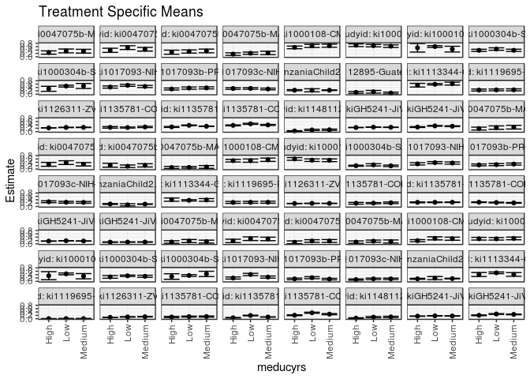

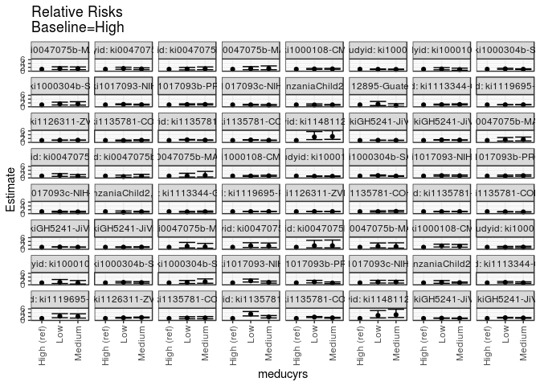

[figure not shown]

[figure not shown]

## Results Table

### Parameter: TSM

| agecat | studyid | country | intervention_level | baseline_level | estimate | ci_lower | ci_upper |
| --- | --- | --- | --- | --- | --- | --- | --- |
| 0-24 months | ki0047075b-MAL-ED | BANGLADESH | High | NA | 0.2532566 | 0.1558177 | 0.3506955 |
| 0-24 months | ki0047075b-MAL-ED | BANGLADESH | Low | NA | 0.3484193 | 0.2352936 | 0.4615451 |
| 0-24 months | ki0047075b-MAL-ED | BANGLADESH | Medium | NA | 0.3316192 | 0.2183021 | 0.4449362 |
| 0-24 months | ki0047075b-MAL-ED | INDIA | High | NA | 0.3848925 | 0.2635749 | 0.5062102 |
| 0-24 months | ki0047075b-MAL-ED | INDIA | Low | NA | 0.5440893 | 0.4321957 | 0.6559830 |
| 0-24 months | ki0047075b-MAL-ED | INDIA | Medium | NA | 0.4461966 | 0.3363609 | 0.5560323 |
| 0-24 months | ki0047075b-MAL-ED | NEPAL | High | NA | 0.2732837 | 0.1516292 | 0.3949382 |
| 0-24 months | ki0047075b-MAL-ED | NEPAL | Low | NA | 0.3136049 | 0.2196024 | 0.4076074 |
| 0-24 months | ki0047075b-MAL-ED | NEPAL | Medium | NA | 0.3480559 | 0.2387824 | 0.4573294 |
| 0-24 months | ki0047075b-MAL-ED | SOUTH AFRICA | High | NA | 0.1593293 | 0.0824233 | 0.2362353 |
| 0-24 months | ki0047075b-MAL-ED | SOUTH AFRICA | Low | NA | 0.2104650 | 0.1435751 | 0.2773549 |
| 0-24 months | ki0047075b-MAL-ED | SOUTH AFRICA | Medium | NA | 0.2262467 | 0.1255643 | 0.3269290 |
| 0-24 months | ki1000108-CMC-V-BCS-2002 | INDIA | High | NA | 0.5574502 | 0.4795341 | 0.6353663 |
| 0-24 months | ki1000108-CMC-V-BCS-2002 | INDIA | Low | NA | 0.6448164 | 0.5531329 | 0.7364998 |
| 0-24 months | ki1000108-CMC-V-BCS-2002 | INDIA | Medium | NA | 0.6566415 | 0.5668611 | 0.7464218 |
| 0-24 months | ki1000108-IRC | INDIA | High | NA | 0.6853316 | 0.6038447 | 0.7668185 |
| 0-24 months | ki1000108-IRC | INDIA | Low | NA | 0.6592369 | 0.5873555 | 0.7311184 |
| 0-24 months | ki1000108-IRC | INDIA | Medium | NA | 0.6286693 | 0.5505443 | 0.7067943 |
| 0-24 months | ki1000109-EE | PAKISTAN | High | NA | 0.5333333 | 0.2805305 | 0.7861362 |
| 0-24 months | ki1000109-EE | PAKISTAN | Low | NA | 0.6079027 | 0.5550776 | 0.6607279 |
| 0-24 months | ki1000109-EE | PAKISTAN | Medium | NA | 0.4545455 | 0.2844331 | 0.6246578 |
| 0-24 months | ki1000304b-SAS-CompFeed | INDIA | High | NA | 0.3832368 | 0.3182062 | 0.4482674 |
| 0-24 months | ki1000304b-SAS-CompFeed | INDIA | Low | NA | 0.4593190 | 0.3865889 | 0.5320491 |
| 0-24 months | ki1000304b-SAS-CompFeed | INDIA | Medium | NA | 0.3840898 | 0.3171385 | 0.4510411 |
| 0-24 months | ki1000304b-SAS-FoodSuppl | INDIA | High | NA | 0.3222833 | 0.1735139 | 0.4710528 |
| 0-24 months | ki1000304b-SAS-FoodSuppl | INDIA | Low | NA | 0.4805575 | 0.4266840 | 0.5344310 |
| 0-24 months | ki1000304b-SAS-FoodSuppl | INDIA | Medium | NA | 0.4880210 | 0.3378404 | 0.6382016 |
| 0-24 months | ki1017093-NIH-Birth | BANGLADESH | High | NA | 0.4243338 | 0.3595864 | 0.4890812 |
| 0-24 months | ki1017093-NIH-Birth | BANGLADESH | Low | NA | 0.5286156 | 0.4686172 | 0.5886141 |
| 0-24 months | ki1017093-NIH-Birth | BANGLADESH | Medium | NA | 0.4590612 | 0.3949197 | 0.5232026 |

[output cut: 162 more lines]

### Parameter: E(Y)

| agecat | studyid | country | intervention_level | baseline_level | estimate | ci_lower | ci_upper |
| --- | --- | --- | --- | --- | --- | --- | --- |
| 0-24 months | ki0047075b-MAL-ED | BANGLADESH | NA | NA | 0.3004695 | 0.2387555 | 0.3621835 |
| 0-24 months | ki0047075b-MAL-ED | INDIA | NA | NA | 0.4727273 | 0.4066048 | 0.5388497 |
| 0-24 months | ki0047075b-MAL-ED | NEPAL | NA | NA | 0.3111111 | 0.2504855 | 0.3717368 |
| 0-24 months | ki0047075b-MAL-ED | SOUTH AFRICA | NA | NA | 0.2051282 | 0.1602507 | 0.2500058 |
| 0-24 months | ki1000108-CMC-V-BCS-2002 | INDIA | NA | NA | 0.6112601 | 0.5617242 | 0.6607959 |
| 0-24 months | ki1000108-IRC | INDIA | NA | NA | 0.6560976 | 0.6100625 | 0.7021326 |
| 0-24 months | ki1000109-EE | PAKISTAN | NA | NA | 0.5915119 | 0.5418269 | 0.6411970 |
| 0-24 months | ki1000304b-SAS-CompFeed | INDIA | NA | NA | 0.4150694 | 0.3581204 | 0.4720184 |
| 0-24 months | ki1000304b-SAS-FoodSuppl | INDIA | NA | NA | 0.4712919 | 0.4233811 | 0.5192026 |
| 0-24 months | ki1017093-NIH-Birth | BANGLADESH | NA | NA | 0.4775641 | 0.4383415 | 0.5167867 |
| 0-24 months | ki1017093b-PROVIDE | BANGLADESH | NA | NA | 0.3514286 | 0.3160364 | 0.3868207 |
| 0-24 months | ki1017093c-NIH-Crypto | BANGLADESH | NA | NA | 0.3298153 | 0.2963239 | 0.3633067 |
| 0-24 months | ki1066203-TanzaniaChild2 | TANZANIA, UNITED REPUBLIC OF | NA | NA | 0.2367980 | 0.2197367 | 0.2538593 |
| 0-24 months | ki1112895-Guatemala BSC | GUATEMALA | NA | NA | 0.1063830 | 0.0703329 | 0.1424331 |
| 0-24 months | ki1113344-GMS-Nepal | NEPAL | NA | NA | 0.5900439 | 0.5531320 | 0.6269559 |
| 0-24 months | ki1119695-PROBIT | BELARUS | NA | NA | 0.2565984 | 0.1993515 | 0.3138454 |
| 0-24 months | ki1126311-ZVITAMBO | ZIMBABWE | NA | NA | 0.2366078 | 0.2295489 | 0.2436667 |
| 0-24 months | ki1135781-COHORTS | GUATEMALA | NA | NA | 0.2564297 | 0.2328823 | 0.2799770 |
| 0-24 months | ki1135781-COHORTS | INDIA | NA | NA | 0.3329911 | 0.3209071 | 0.3450751 |
| 0-24 months | ki1135781-COHORTS | PHILIPPINES | NA | NA | 0.4036125 | 0.3861835 | 0.4210415 |
| 0-24 months | ki1148112-LCNI-5 | MALAWI | NA | NA | 0.0798526 | 0.0612199 | 0.0984853 |
| 0-24 months | kiGH5241-JiVitA-3 | BANGLADESH | NA | NA | 0.2580418 | 0.2515722 | 0.2645113 |
| 0-24 months | kiGH5241-JiVitA-4 | BANGLADESH | NA | NA | 0.3105166 | 0.2961054 | 0.3249278 |
| 0-6 months | ki0047075b-MAL-ED | BANGLADESH | NA | NA | 0.2253521 | 0.1691098 | 0.2815944 |
| 0-6 months | ki0047075b-MAL-ED | INDIA | NA | NA | 0.3181818 | 0.2564942 | 0.3798694 |
| 0-6 months | ki0047075b-MAL-ED | NEPAL | NA | NA | 0.2000000 | 0.1476178 | 0.2523822 |
| 0-6 months | ki0047075b-MAL-ED | SOUTH AFRICA | NA | NA | 0.1121795 | 0.0771053 | 0.1472536 |
| 0-6 months | ki1000108-CMC-V-BCS-2002 | INDIA | NA | NA | 0.5163043 | 0.4651769 | 0.5674318 |
| 0-6 months | ki1000108-IRC | INDIA | NA | NA | 0.5439024 | 0.4956326 | 0.5921723 |
| 0-6 months | ki1000304b-SAS-CompFeed | INDIA | NA | NA | 0.2199336 | 0.1753445 | 0.2645227 |
| 0-6 months | ki1017093-NIH-Birth | BANGLADESH | NA | NA | 0.3569132 | 0.3192325 | 0.3945938 |
| 0-6 months | ki1017093b-PROVIDE | BANGLADESH | NA | NA | 0.2585714 | 0.2261125 | 0.2910304 |
| 0-6 months | ki1017093c-NIH-Crypto | BANGLADESH | NA | NA | 0.2572559 | 0.2261171 | 0.2883948 |
| 0-6 months | ki1066203-TanzaniaChild2 | TANZANIA, UNITED REPUBLIC OF | NA | NA | 0.1395641 | 0.1256566 | 0.1534717 |
| 0-6 months | ki1113344-GMS-Nepal | NEPAL | NA | NA | 0.3762811 | 0.3399226 | 0.4126397 |
| 0-6 months | ki1119695-PROBIT | BELARUS | NA | NA | 0.2497780 | 0.1917926 | 0.3077635 |
| 0-6 months | ki1126311-ZVITAMBO | ZIMBABWE | NA | NA | 0.1810164 | 0.1745999 | 0.1874330 |
| 0-6 months | ki1135781-COHORTS | GUATEMALA | NA | NA | 0.2007612 | 0.1765324 | 0.2249900 |
| 0-6 months | ki1135781-COHORTS | INDIA | NA | NA | 0.2511554 | 0.2398221 | 0.2624886 |
| 0-6 months | ki1135781-COHORTS | PHILIPPINES | NA | NA | 0.2355453 | 0.2204685 | 0.2506222 |
| 0-6 months | kiGH5241-JiVitA-3 | BANGLADESH | NA | NA | 0.1762162 | 0.1705869 | 0.1818456 |
| 0-6 months | kiGH5241-JiVitA-4 | BANGLADESH | NA | NA | 0.1079378 | 0.0980978 | 0.1177778 |
| 6-24 months | ki0047075b-MAL-ED | BANGLADESH | NA | NA | 0.1384615 | 0.0898601 | 0.1870630 |
| 6-24 months | ki0047075b-MAL-ED | INDIA | NA | NA | 0.2657005 | 0.2053824 | 0.3260185 |
| 6-24 months | ki0047075b-MAL-ED | NEPAL | NA | NA | 0.1545455 | 0.1066715 | 0.2024194 |
| 6-24 months | ki0047075b-MAL-ED | SOUTH AFRICA | NA | NA | 0.1428571 | 0.1001583 | 0.1855560 |
| 6-24 months | ki1000108-CMC-V-BCS-2002 | INDIA | NA | NA | 0.2654155 | 0.2205451 | 0.3102860 |
| 6-24 months | ki1000108-IRC | INDIA | NA | NA | 0.3097561 | 0.2649438 | 0.3545684 |
| 6-24 months | ki1000109-EE | PAKISTAN | NA | NA | 0.4258760 | 0.3754921 | 0.4762599 |
| 6-24 months | ki1000304b-SAS-CompFeed | INDIA | NA | NA | 0.3059755 | 0.2638053 | 0.3481458 |
| 6-24 months | ki1000304b-SAS-FoodSuppl | INDIA | NA | NA | 0.3557214 | 0.3088651 | 0.4025777 |
| 6-24 months | ki1017093-NIH-Birth | BANGLADESH | NA | NA | 0.2933579 | 0.2549918 | 0.3317241 |
| 6-24 months | ki1017093b-PROVIDE | BANGLADESH | NA | NA | 0.1609756 | 0.1319065 | 0.1900447 |
| 6-24 months | ki1017093c-NIH-Crypto | BANGLADESH | NA | NA | 0.1315069 | 0.1069744 | 0.1560393 |
| 6-24 months | ki1066203-TanzaniaChild2 | TANZANIA, UNITED REPUBLIC OF | NA | NA | 0.1606166 | 0.1445647 | 0.1766685 |
| 6-24 months | ki1113344-GMS-Nepal | NEPAL | NA | NA | 0.4735945 | 0.4331684 | 0.5140207 |
| 6-24 months | ki1119695-PROBIT | BELARUS | NA | NA | 0.0100615 | 0.0072668 | 0.0128561 |
| 6-24 months | ki1126311-ZVITAMBO | ZIMBABWE | NA | NA | 0.0959259 | 0.0903717 | 0.1014802 |
| 6-24 months | ki1135781-COHORTS | GUATEMALA | NA | NA | 0.1277129 | 0.1088047 | 0.1466210 |
| 6-24 months | ki1135781-COHORTS | INDIA | NA | NA | 0.1266654 | 0.1178579 | 0.1354730 |
| 6-24 months | ki1135781-COHORTS | PHILIPPINES | NA | NA | 0.2666429 | 0.2502871 | 0.2829988 |
| 6-24 months | ki1148112-LCNI-5 | MALAWI | NA | NA | 0.0772105 | 0.0587369 | 0.0956840 |
| 6-24 months | kiGH5241-JiVitA-3 | BANGLADESH | NA | NA | 0.1638889 | 0.1577625 | 0.1700152 |
| 6-24 months | kiGH5241-JiVitA-4 | BANGLADESH | NA | NA | 0.2475997 | 0.2340658 | 0.2611337 |

### Parameter: RR

| agecat | studyid | country | intervention_level | baseline_level | estimate | ci_lower | ci_upper |
| --- | --- | --- | --- | --- | --- | --- | --- |
| 0-24 months | ki0047075b-MAL-ED | BANGLADESH | High | High | 1.0000000 | 1.0000000 | 1.0000000 |
| 0-24 months | ki0047075b-MAL-ED | BANGLADESH | Low | High | 1.3757562 | 0.8310028 | 2.2776158 |
| 0-24 months | ki0047075b-MAL-ED | BANGLADESH | Medium | High | 1.3094196 | 0.7809553 | 2.1954902 |
| 0-24 months | ki0047075b-MAL-ED | INDIA | High | High | 1.0000000 | 1.0000000 | 1.0000000 |
| 0-24 months | ki0047075b-MAL-ED | INDIA | Low | High | 1.4136137 | 0.9689888 | 2.0622567 |
| 0-24 months | ki0047075b-MAL-ED | INDIA | Medium | High | 1.1592759 | 0.7772166 | 1.7291454 |
| 0-24 months | ki0047075b-MAL-ED | NEPAL | High | High | 1.0000000 | 1.0000000 | 1.0000000 |
| 0-24 months | ki0047075b-MAL-ED | NEPAL | Low | High | 1.1475435 | 0.6700354 | 1.9653528 |
| 0-24 months | ki0047075b-MAL-ED | NEPAL | Medium | High | 1.2736066 | 0.7381481 | 2.1974910 |
| 0-24 months | ki0047075b-MAL-ED | SOUTH AFRICA | High | High | 1.0000000 | 1.0000000 | 1.0000000 |
| 0-24 months | ki0047075b-MAL-ED | SOUTH AFRICA | Low | High | 1.3209436 | 0.7405867 | 2.3560943 |
| 0-24 months | ki0047075b-MAL-ED | SOUTH AFRICA | Medium | High | 1.4199943 | 0.7355865 | 2.7411921 |
| 0-24 months | ki1000108-CMC-V-BCS-2002 | INDIA | High | High | 1.0000000 | 1.0000000 | 1.0000000 |
| 0-24 months | ki1000108-CMC-V-BCS-2002 | INDIA | Low | High | 1.1567246 | 0.9475104 | 1.4121341 |
| 0-24 months | ki1000108-CMC-V-BCS-2002 | INDIA | Medium | High | 1.1779375 | 0.9693234 | 1.4314486 |
| 0-24 months | ki1000108-IRC | INDIA | High | High | 1.0000000 | 1.0000000 | 1.0000000 |
| 0-24 months | ki1000108-IRC | INDIA | Low | High | 0.9619240 | 0.8222317 | 1.1253491 |
| 0-24 months | ki1000108-IRC | INDIA | Medium | High | 0.9173214 | 0.7742583 | 1.0868187 |
| 0-24 months | ki1000109-EE | PAKISTAN | High | High | 1.0000000 | 1.0000000 | 1.0000000 |
| 0-24 months | ki1000109-EE | PAKISTAN | Low | High | 1.1398176 | 0.7039580 | 1.8455421 |
| 0-24 months | ki1000109-EE | PAKISTAN | Medium | High | 0.8522727 | 0.4658985 | 1.5590708 |
| 0-24 months | ki1000304b-SAS-CompFeed | INDIA | High | High | 1.0000000 | 1.0000000 | 1.0000000 |
| 0-24 months | ki1000304b-SAS-CompFeed | INDIA | Low | High | 1.1985253 | 0.9790858 | 1.4671470 |
| 0-24 months | ki1000304b-SAS-CompFeed | INDIA | Medium | High | 1.0022258 | 0.8289513 | 1.2117197 |
| 0-24 months | ki1000304b-SAS-FoodSuppl | INDIA | High | High | 1.0000000 | 1.0000000 | 1.0000000 |
| 0-24 months | ki1000304b-SAS-FoodSuppl | INDIA | Low | High | 1.4911025 | 0.9272969 | 2.3977073 |
| 0-24 months | ki1000304b-SAS-FoodSuppl | INDIA | Medium | High | 1.5142606 | 0.8689464 | 2.6388110 |
| 0-24 months | ki1017093-NIH-Birth | BANGLADESH | High | High | 1.0000000 | 1.0000000 | 1.0000000 |
| 0-24 months | ki1017093-NIH-Birth | BANGLADESH | Low | High | 1.2457542 | 1.0406024 | 1.4913511 |
| 0-24 months | ki1017093-NIH-Birth | BANGLADESH | Medium | High | 1.0818396 | 0.8881677 | 1.3177433 |

[output cut: 162 more lines]

### Parameter: PAR

| agecat | studyid | country | intervention_level | baseline_level | estimate | ci_lower | ci_upper |
| --- | --- | --- | --- | --- | --- | --- | --- |
| 0-24 months | ki0047075b-MAL-ED | BANGLADESH | High | NA | 0.0472129 | -0.0337080 | 0.1281337 |
| 0-24 months | ki0047075b-MAL-ED | INDIA | High | NA | 0.0878348 | -0.0159700 | 0.1916395 |
| 0-24 months | ki0047075b-MAL-ED | NEPAL | High | NA | 0.0378274 | -0.0705064 | 0.1461613 |
| 0-24 months | ki0047075b-MAL-ED | SOUTH AFRICA | High | NA | 0.0457989 | -0.0207528 | 0.1123507 |
| 0-24 months | ki1000108-CMC-V-BCS-2002 | INDIA | High | NA | 0.0538098 | -0.0047353 | 0.1123550 |
| 0-24 months | ki1000108-IRC | INDIA | High | NA | -0.0292340 | -0.0960349 | 0.0375668 |
| 0-24 months | ki1000109-EE | PAKISTAN | High | NA | 0.0581786 | -0.1893941 | 0.3057514 |
| 0-24 months | ki1000304b-SAS-CompFeed | INDIA | High | NA | 0.0318326 | -0.0280240 | 0.0916891 |
| 0-24 months | ki1000304b-SAS-FoodSuppl | INDIA | High | NA | 0.1490085 | 0.0068495 | 0.2911675 |
| 0-24 months | ki1017093-NIH-Birth | BANGLADESH | High | NA | 0.0532303 | 0.0001997 | 0.1062608 |
| 0-24 months | ki1017093b-PROVIDE | BANGLADESH | High | NA | 0.0422153 | -0.0068251 | 0.0912557 |
| 0-24 months | ki1017093c-NIH-Crypto | BANGLADESH | High | NA | -0.0098157 | -0.0490652 | 0.0294339 |
| 0-24 months | ki1066203-TanzaniaChild2 | TANZANIA, UNITED REPUBLIC OF | High | NA | -0.0012068 | -0.0302122 | 0.0277987 |
| 0-24 months | ki1112895-Guatemala BSC | GUATEMALA | High | NA | -0.0037865 | -0.0464720 | 0.0388989 |
| 0-24 months | ki1113344-GMS-Nepal | NEPAL | High | NA | 0.0546026 | -0.0469885 | 0.1561937 |
| 0-24 months | ki1119695-PROBIT | BELARUS | High | NA | 0.0105173 | -0.0021419 | 0.0231765 |
| 0-24 months | ki1126311-ZVITAMBO | ZIMBABWE | High | NA | 0.0134530 | 0.0084807 | 0.0184253 |
| 0-24 months | ki1135781-COHORTS | GUATEMALA | High | NA | 0.0029251 | -0.0358183 | 0.0416686 |
| 0-24 months | ki1135781-COHORTS | INDIA | High | NA | 0.0547225 | 0.0279482 | 0.0814969 |
| 0-24 months | ki1135781-COHORTS | PHILIPPINES | High | NA | 0.0308627 | 0.0097061 | 0.0520192 |
| 0-24 months | ki1148112-LCNI-5 | MALAWI | High | NA | 0.0438164 | 0.0222655 | 0.0653673 |
| 0-24 months | kiGH5241-JiVitA-3 | BANGLADESH | High | NA | 0.0122318 | 0.0042201 | 0.0202436 |
| 0-24 months | kiGH5241-JiVitA-4 | BANGLADESH | High | NA | 0.0385444 | 0.0199978 | 0.0570911 |
| 0-6 months | ki0047075b-MAL-ED | BANGLADESH | High | NA | 0.0453480 | -0.0266973 | 0.1173933 |
| 0-6 months | ki0047075b-MAL-ED | INDIA | High | NA | 0.0386137 | -0.0603825 | 0.1376100 |
| 0-6 months | ki0047075b-MAL-ED | NEPAL | High | NA | -0.0262658 | -0.1254958 | 0.0729643 |
| 0-6 months | ki0047075b-MAL-ED | SOUTH AFRICA | High | NA | 0.0181648 | -0.0356407 | 0.0719703 |
| 0-6 months | ki1000108-CMC-V-BCS-2002 | INDIA | High | NA | 0.0181293 | -0.0415086 | 0.0777671 |
| 0-6 months | ki1000108-IRC | INDIA | High | NA | -0.0564095 | -0.1230930 | 0.0102739 |
| 0-6 months | ki1000304b-SAS-CompFeed | INDIA | High | NA | 0.0208856 | -0.0077576 | 0.0495289 |
| 0-6 months | ki1017093-NIH-Birth | BANGLADESH | High | NA | 0.0465634 | -0.0126143 | 0.1057411 |
| 0-6 months | ki1017093b-PROVIDE | BANGLADESH | High | NA | 0.0125008 | -0.0335263 | 0.0585279 |
| 0-6 months | ki1017093c-NIH-Crypto | BANGLADESH | High | NA | -0.0220063 | -0.0642683 | 0.0202557 |
| 0-6 months | ki1066203-TanzaniaChild2 | TANZANIA, UNITED REPUBLIC OF | High | NA | -0.0069737 | -0.0307331 | 0.0167856 |
| 0-6 months | ki1113344-GMS-Nepal | NEPAL | High | NA | -0.0306305 | -0.1192023 | 0.0579413 |
| 0-6 months | ki1119695-PROBIT | BELARUS | High | NA | 0.0086562 | -0.0034470 | 0.0207594 |
| 0-6 months | ki1126311-ZVITAMBO | ZIMBABWE | High | NA | 0.0038469 | 0.0003608 | 0.0073329 |
| 0-6 months | ki1135781-COHORTS | GUATEMALA | High | NA | 0.0098043 | -0.0377686 | 0.0573772 |
| 0-6 months | ki1135781-COHORTS | INDIA | High | NA | 0.0060035 | -0.0174170 | 0.0294239 |
| 0-6 months | ki1135781-COHORTS | PHILIPPINES | High | NA | -0.0179351 | -0.0335010 | -0.0023692 |
| 0-6 months | kiGH5241-JiVitA-3 | BANGLADESH | High | NA | 0.0107256 | 0.0049226 | 0.0165286 |
| 0-6 months | kiGH5241-JiVitA-4 | BANGLADESH | High | NA | 0.0034330 | -0.0068525 | 0.0137185 |
| 6-24 months | ki0047075b-MAL-ED | BANGLADESH | High | NA | 0.0257855 | -0.0361817 | 0.0877527 |
| 6-24 months | ki0047075b-MAL-ED | INDIA | High | NA | 0.0864978 | -0.0045836 | 0.1775793 |
| 6-24 months | ki0047075b-MAL-ED | NEPAL | High | NA | 0.0583916 | -0.0170578 | 0.1338410 |
| 6-24 months | ki0047075b-MAL-ED | SOUTH AFRICA | High | NA | 0.0347490 | -0.0283117 | 0.0978098 |
| 6-24 months | ki1000108-CMC-V-BCS-2002 | INDIA | High | NA | 0.0724814 | 0.0204034 | 0.1245593 |
| 6-24 months | ki1000108-IRC | INDIA | High | NA | 0.0014333 | -0.0668369 | 0.0697034 |
| 6-24 months | ki1000109-EE | PAKISTAN | High | NA | 0.0925427 | -0.1419536 | 0.3270389 |
| 6-24 months | ki1000304b-SAS-CompFeed | INDIA | High | NA | 0.0437282 | -0.0265478 | 0.1140042 |
| 6-24 months | ki1000304b-SAS-FoodSuppl | INDIA | High | NA | 0.0715632 | -0.0855215 | 0.2286479 |
| 6-24 months | ki1017093-NIH-Birth | BANGLADESH | High | NA | 0.0967897 | 0.0399743 | 0.1536051 |
| 6-24 months | ki1017093b-PROVIDE | BANGLADESH | High | NA | 0.0155343 | -0.0239425 | 0.0550110 |
| 6-24 months | ki1017093c-NIH-Crypto | BANGLADESH | High | NA | 0.0285762 | -0.0038561 | 0.0610084 |
| 6-24 months | ki1066203-TanzaniaChild2 | TANZANIA, UNITED REPUBLIC OF | High | NA | 0.0123264 | -0.0146555 | 0.0393084 |
| 6-24 months | ki1113344-GMS-Nepal | NEPAL | High | NA | 0.0706917 | -0.0401219 | 0.1815053 |
| 6-24 months | ki1119695-PROBIT | BELARUS | High | NA | 0.0047963 | 0.0020375 | 0.0075550 |
| 6-24 months | ki1126311-ZVITAMBO | ZIMBABWE | High | NA | 0.0147428 | 0.0088543 | 0.0206312 |
| 6-24 months | ki1135781-COHORTS | GUATEMALA | High | NA | 0.0252903 | -0.0074235 | 0.0580041 |
| 6-24 months | ki1135781-COHORTS | INDIA | High | NA | 0.0676559 | 0.0478999 | 0.0874118 |
| 6-24 months | ki1135781-COHORTS | PHILIPPINES | High | NA | 0.0587961 | 0.0368845 | 0.0807077 |
| 6-24 months | ki1148112-LCNI-5 | MALAWI | High | NA | 0.0404814 | 0.0189815 | 0.0619813 |
| 6-24 months | kiGH5241-JiVitA-3 | BANGLADESH | High | NA | 0.0095504 | -0.0000493 | 0.0191501 |
| 6-24 months | kiGH5241-JiVitA-4 | BANGLADESH | High | NA | 0.0432577 | 0.0255906 | 0.0609248 |

### Parameter: PAF

| agecat | studyid | country | intervention_level | baseline_level | estimate | ci_lower | ci_upper |
| --- | --- | --- | --- | --- | --- | --- | --- |
| 0-24 months | ki0047075b-MAL-ED | BANGLADESH | High | NA | 0.1571304 | -0.1590080 | 0.3870368 |
| 0-24 months | ki0047075b-MAL-ED | INDIA | High | NA | 0.1858043 | -0.0671933 | 0.3788242 |
| 0-24 months | ki0047075b-MAL-ED | NEPAL | High | NA | 0.1215882 | -0.3053050 | 0.4088682 |
| 0-24 months | ki0047075b-MAL-ED | SOUTH AFRICA | High | NA | 0.2232698 | -0.1784564 | 0.4880508 |
| 0-24 months | ki1000108-CMC-V-BCS-2002 | INDIA | High | NA | 0.0880310 | -0.0135099 | 0.1793988 |
| 0-24 months | ki1000108-IRC | INDIA | High | NA | -0.0445574 | -0.1515203 | 0.0524698 |
| 0-24 months | ki1000109-EE | PAKISTAN | High | NA | 0.0983558 | -0.4344899 | 0.4332743 |
| 0-24 months | ki1000304b-SAS-CompFeed | INDIA | High | NA | 0.0766922 | -0.0751048 | 0.2070565 |
| 0-24 months | ki1000304b-SAS-FoodSuppl | INDIA | High | NA | 0.3161704 | -0.0642508 | 0.5606083 |
| 0-24 months | ki1017093-NIH-Birth | BANGLADESH | High | NA | 0.1114621 | -0.0068514 | 0.2158727 |
| 0-24 months | ki1017093b-PROVIDE | BANGLADESH | High | NA | 0.1201248 | -0.0307869 | 0.2489423 |
| 0-24 months | ki1017093c-NIH-Crypto | BANGLADESH | High | NA | -0.0297611 | -0.1558446 | 0.0825688 |
| 0-24 months | ki1066203-TanzaniaChild2 | TANZANIA, UNITED REPUBLIC OF | High | NA | -0.0050963 | -0.1353624 | 0.1102238 |
| 0-24 months | ki1112895-Guatemala BSC | GUATEMALA | High | NA | -0.0355932 | -0.5254587 | 0.2969634 |
| 0-24 months | ki1113344-GMS-Nepal | NEPAL | High | NA | 0.0925400 | -0.0973381 | 0.2495624 |
| 0-24 months | ki1119695-PROBIT | BELARUS | High | NA | 0.0409874 | -0.0107409 | 0.0900683 |
| 0-24 months | ki1126311-ZVITAMBO | ZIMBABWE | High | NA | 0.0568579 | 0.0356696 | 0.0775807 |
| 0-24 months | ki1135781-COHORTS | GUATEMALA | High | NA | 0.0114072 | -0.1518191 | 0.1515024 |
| 0-24 months | ki1135781-COHORTS | INDIA | High | NA | 0.1643364 | 0.0800790 | 0.2408764 |
| 0-24 months | ki1135781-COHORTS | PHILIPPINES | High | NA | 0.0764661 | 0.0225613 | 0.1273980 |
| 0-24 months | ki1148112-LCNI-5 | MALAWI | High | NA | 0.5487165 | 0.2305253 | 0.7353301 |
| 0-24 months | kiGH5241-JiVitA-3 | BANGLADESH | High | NA | 0.0474025 | 0.0158735 | 0.0779214 |
| 0-24 months | kiGH5241-JiVitA-4 | BANGLADESH | High | NA | 0.1241300 | 0.0619854 | 0.1821574 |
| 0-6 months | ki0047075b-MAL-ED | BANGLADESH | High | NA | 0.2012317 | -0.1885581 | 0.4631892 |
| 0-6 months | ki0047075b-MAL-ED | INDIA | High | NA | 0.1213575 | -0.2524672 | 0.3836065 |
| 0-6 months | ki0047075b-MAL-ED | NEPAL | High | NA | -0.1313288 | -0.7528610 | 0.2698196 |
| 0-6 months | ki0047075b-MAL-ED | SOUTH AFRICA | High | NA | 0.1619264 | -0.4872231 | 0.5277323 |
| 0-6 months | ki1000108-CMC-V-BCS-2002 | INDIA | High | NA | 0.0351135 | -0.0876587 | 0.1440275 |
| 0-6 months | ki1000108-IRC | INDIA | High | NA | -0.1037126 | -0.2339288 | 0.0127619 |
| 0-6 months | ki1000304b-SAS-CompFeed | INDIA | High | NA | 0.0949633 | -0.0306635 | 0.2052775 |
| 0-6 months | ki1017093-NIH-Birth | BANGLADESH | High | NA | 0.1304615 | -0.0522121 | 0.2814212 |
| 0-6 months | ki1017093b-PROVIDE | BANGLADESH | High | NA | 0.0483457 | -0.1469478 | 0.2103861 |
| 0-6 months | ki1017093c-NIH-Crypto | BANGLADESH | High | NA | -0.0855424 | -0.2630435 | 0.0670136 |
| 0-6 months | ki1066203-TanzaniaChild2 | TANZANIA, UNITED REPUBLIC OF | High | NA | -0.0499678 | -0.2347294 | 0.1071465 |
| 0-6 months | ki1113344-GMS-Nepal | NEPAL | High | NA | -0.0814033 | -0.3441851 | 0.1300059 |
| 0-6 months | ki1119695-PROBIT | BELARUS | High | NA | 0.0346556 | -0.0153993 | 0.0822430 |
| 0-6 months | ki1126311-ZVITAMBO | ZIMBABWE | High | NA | 0.0212515 | 0.0018171 | 0.0403075 |
| 0-6 months | ki1135781-COHORTS | GUATEMALA | High | NA | 0.0488357 | -0.2200494 | 0.2584616 |
| 0-6 months | ki1135781-COHORTS | INDIA | High | NA | 0.0239033 | -0.0739291 | 0.1128235 |
| 0-6 months | ki1135781-COHORTS | PHILIPPINES | High | NA | -0.0761430 | -0.1442953 | -0.0120497 |
| 0-6 months | kiGH5241-JiVitA-3 | BANGLADESH | High | NA | 0.0608661 | 0.0273236 | 0.0932518 |
| 0-6 months | kiGH5241-JiVitA-4 | BANGLADESH | High | NA | 0.0318053 | -0.0686390 | 0.1228086 |
| 6-24 months | ki0047075b-MAL-ED | BANGLADESH | High | NA | 0.1862285 | -0.4042934 | 0.5284290 |
| 6-24 months | ki0047075b-MAL-ED | INDIA | High | NA | 0.3255464 | -0.1140234 | 0.5916714 |
| 6-24 months | ki0047075b-MAL-ED | NEPAL | High | NA | 0.3778280 | -0.3397954 | 0.7110768 |
| 6-24 months | ki0047075b-MAL-ED | SOUTH AFRICA | High | NA | 0.2432432 | -0.3480406 | 0.5751754 |
| 6-24 months | ki1000108-CMC-V-BCS-2002 | INDIA | High | NA | 0.2730864 | 0.0518082 | 0.4427253 |
| 6-24 months | ki1000108-IRC | INDIA | High | NA | 0.0046271 | -0.2420774 | 0.2023306 |
| 6-24 months | ki1000109-EE | PAKISTAN | High | NA | 0.2172996 | -0.5818690 | 0.6127240 |
| 6-24 months | ki1000304b-SAS-CompFeed | INDIA | High | NA | 0.1429141 | -0.1191641 | 0.3436206 |
| 6-24 months | ki1000304b-SAS-FoodSuppl | INDIA | High | NA | 0.2011778 | -0.3906699 | 0.5411442 |
| 6-24 months | ki1017093-NIH-Birth | BANGLADESH | High | NA | 0.3299371 | 0.1084749 | 0.4963863 |
| 6-24 months | ki1017093b-PROVIDE | BANGLADESH | High | NA | 0.0965007 | -0.1844822 | 0.3108288 |
| 6-24 months | ki1017093c-NIH-Crypto | BANGLADESH | High | NA | 0.2172979 | -0.0675994 | 0.4261681 |
| 6-24 months | ki1066203-TanzaniaChild2 | TANZANIA, UNITED REPUBLIC OF | High | NA | 0.0767443 | -0.1073733 | 0.2302496 |
| 6-24 months | ki1113344-GMS-Nepal | NEPAL | High | NA | 0.1492662 | -0.1198983 | 0.3537378 |
| 6-24 months | ki1119695-PROBIT | BELARUS | High | NA | 0.4766972 | 0.1976983 | 0.6586748 |
| 6-24 months | ki1126311-ZVITAMBO | ZIMBABWE | High | NA | 0.1536893 | 0.0907080 | 0.2123082 |
| 6-24 months | ki1135781-COHORTS | GUATEMALA | High | NA | 0.1980244 | -0.1017159 | 0.4162153 |
| 6-24 months | ki1135781-COHORTS | INDIA | High | NA | 0.5341305 | 0.3553665 | 0.6633213 |
| 6-24 months | ki1135781-COHORTS | PHILIPPINES | High | NA | 0.2205050 | 0.1345991 | 0.2978833 |
| 6-24 months | ki1148112-LCNI-5 | MALAWI | High | NA | 0.5242993 | 0.1931747 | 0.7195290 |
| 6-24 months | kiGH5241-JiVitA-3 | BANGLADESH | High | NA | 0.0582736 | -0.0020818 | 0.1149939 |
| 6-24 months | kiGH5241-JiVitA-4 | BANGLADESH | High | NA | 0.1747082 | 0.1000126 | 0.2432043 |